# IE360 Homework 4-5

##Intro

In this homework, the data obtained for the term project is used again. The sold count datas are analysed, appropriate ARIMA models were applied, regressors that can improve the model were found, and lastly, the found regressors were used with the ARIMA models in order to see how the model improves, or if it improves.

Since one week period will be tested, in order to be able to find the amount of deviation from the actual values, we omitted the last 7 days from the data so that we can compare our predictions to actual results.

## Question 1

### Bikini Top 1

The plot of bikini top 1 is below.

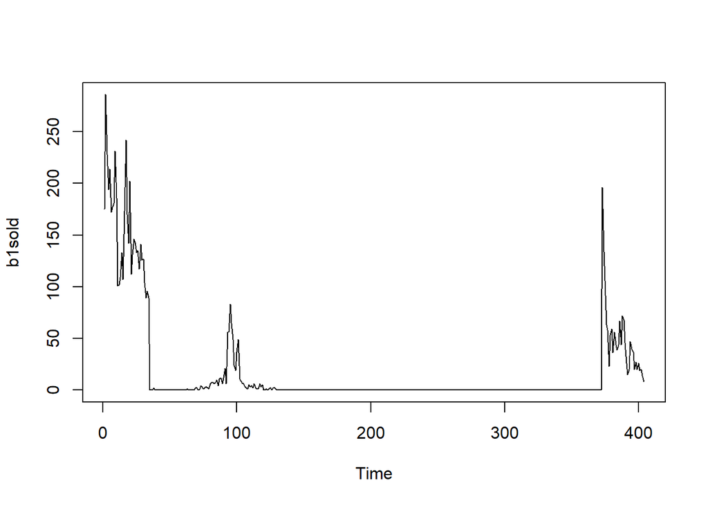

The plot above shows that the sales increase and fluctuate during spring time and mostly 0 otherwise.

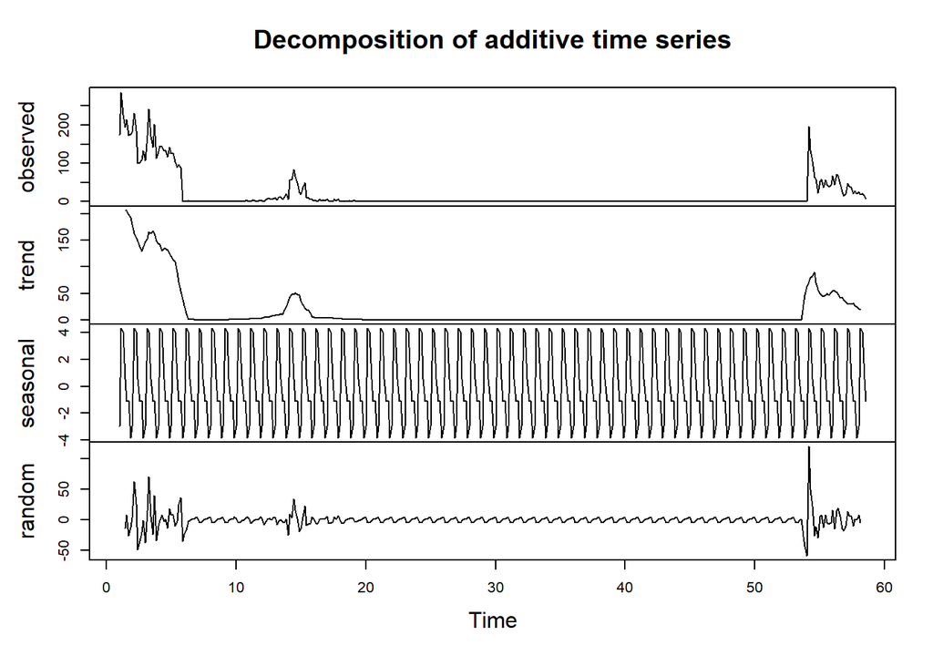

```
##
##  KPSS Test for Level Stationarity
##
## data:  random_b1
## KPSS Level = 0.020598, Truncation lag parameter = 5, p-value = 0.1
```

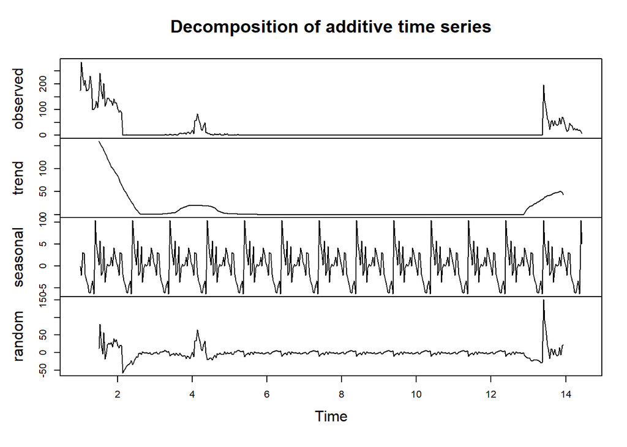

```
##
##  KPSS Test for Level Stationarity
##
## data:  random_b11
## KPSS Level = 0.031933, Truncation lag parameter = 5, p-value = 0.1
```

Both of the random components of the compositions are stationary, according to the KPSS test. However, we continued with weekly decompositions since the data having weekly seasonality made more sense than the data having monthly seasonality as the product is a clothing.

### Bikini Top 2

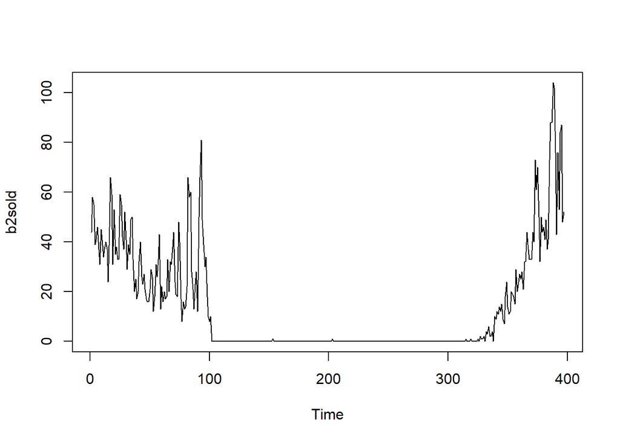

Likewise, apart from the ends of the plot, the sales is mostly 0. Hence, a seasonality is on the table. The sales seem to fluctuate during mostly hot months.

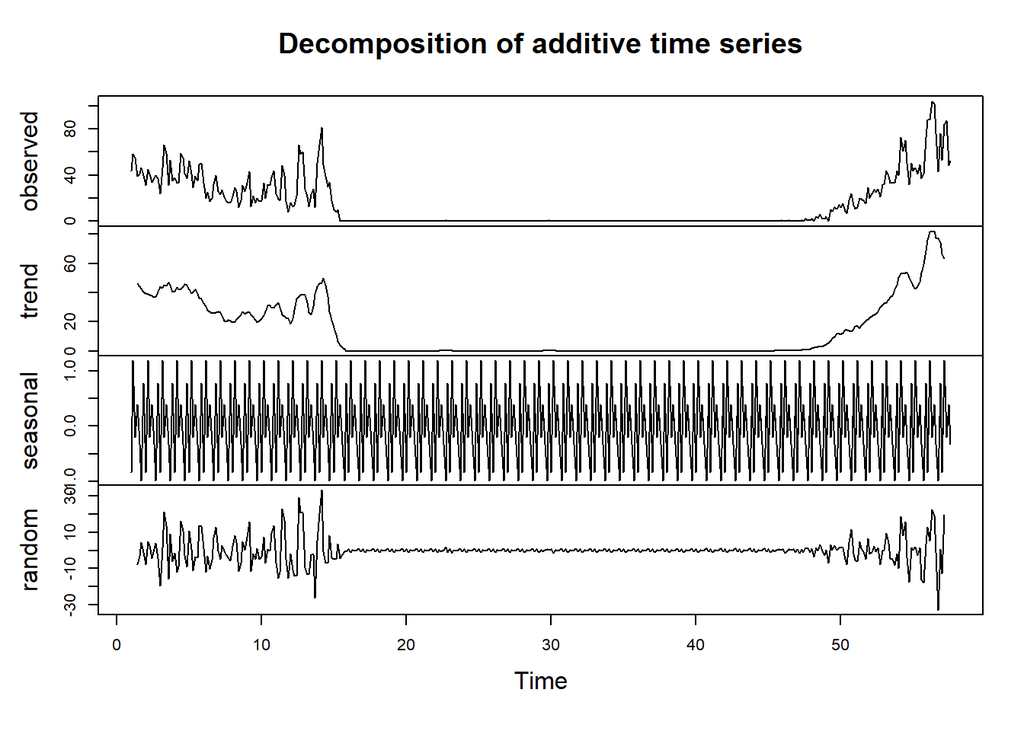

```
##
##  KPSS Test for Level Stationarity
##
## data:  random_b2
## KPSS Level = 0.012264, Truncation lag parameter = 5, p-value = 0.1
```

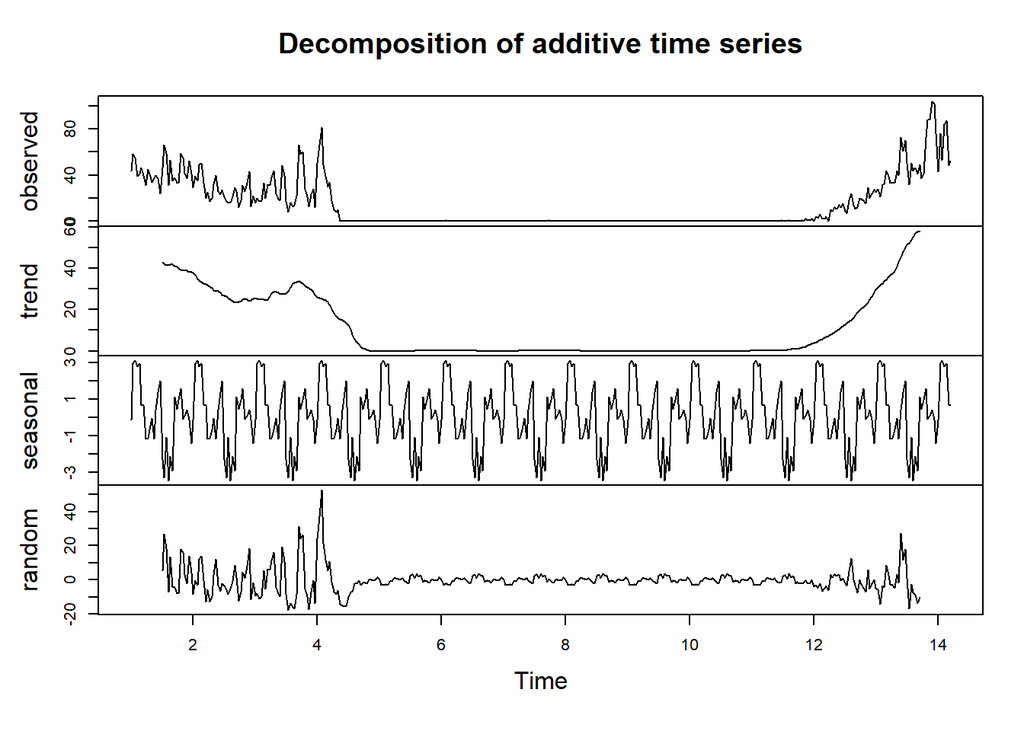

```
##
##  KPSS Test for Level Stationarity
##
## data:  random_b22
## KPSS Level = 0.088026, Truncation lag parameter = 5, p-value = 0.1
```

Again, the KPSS test suggests that both the random components of the decompositions are stationary. However, as this product is also a clothing item, we chose to continue with the weekly decomposition.

### Coat

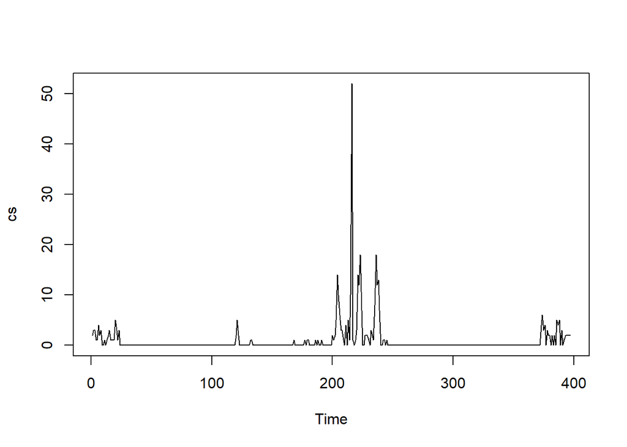

According to the plot above, this product seems to sell at the middle of the plot, the relatively cold months. Although same period of the year before is not available, we can argue about a seasonality here.

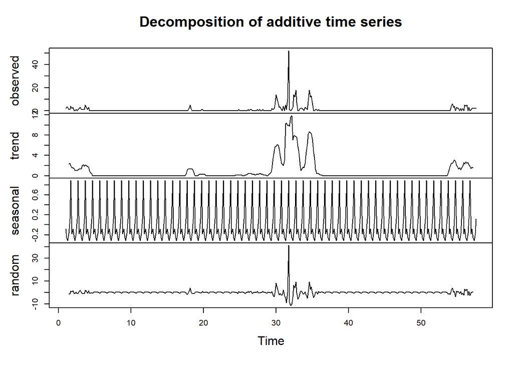

```
##
##  KPSS Test for Level Stationarity
##
## data:  random_cs
## KPSS Level = 0.0090954, Truncation lag parameter = 5, p-value = 0.1
```

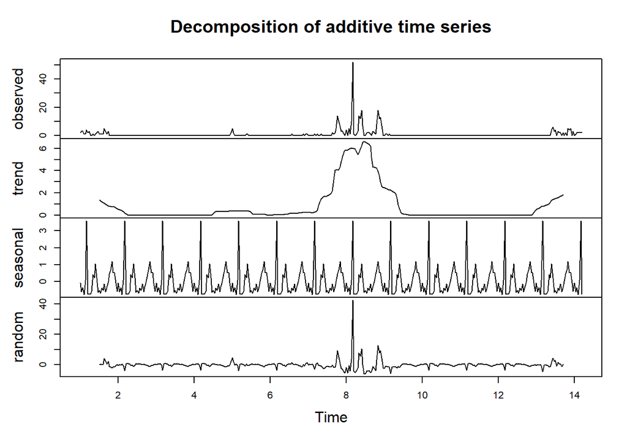

```
##
##  KPSS Test for Level Stationarity
##
## data:  random_css
## KPSS Level = 0.0001512, Truncation lag parameter = 5, p-value = 0.1
```

Again, the KPSS test suggests that the random components of both decomposiitons are stationary. Yet, as we think that the product is more likely to have a weekly pattern, we followed the weekly decomposiiton.

### Tights

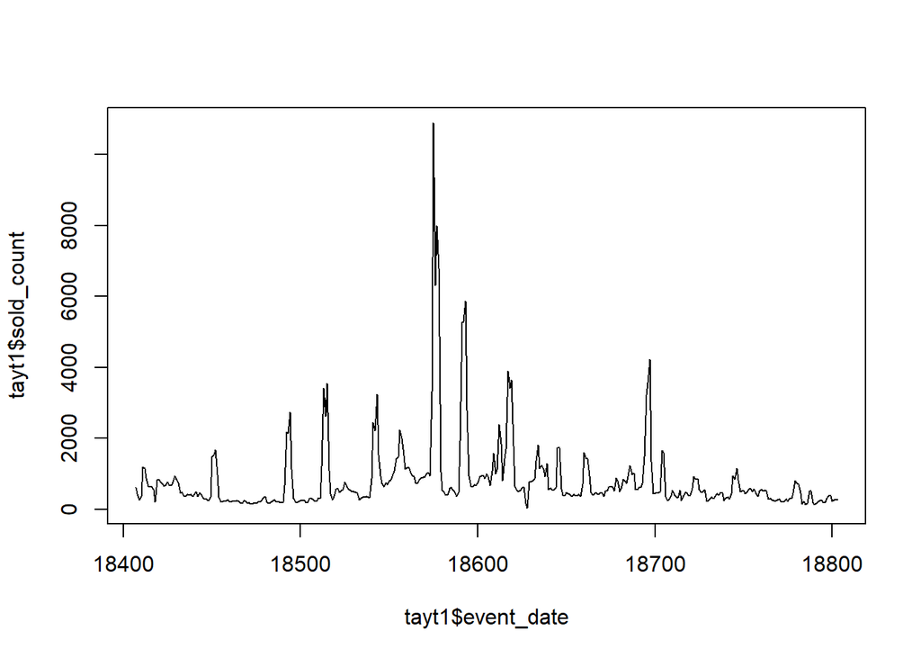

There are some fluctuations due to discount periods.

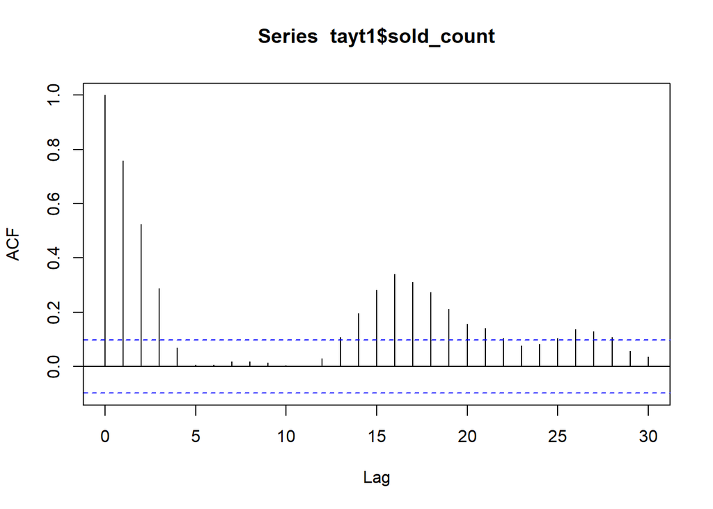

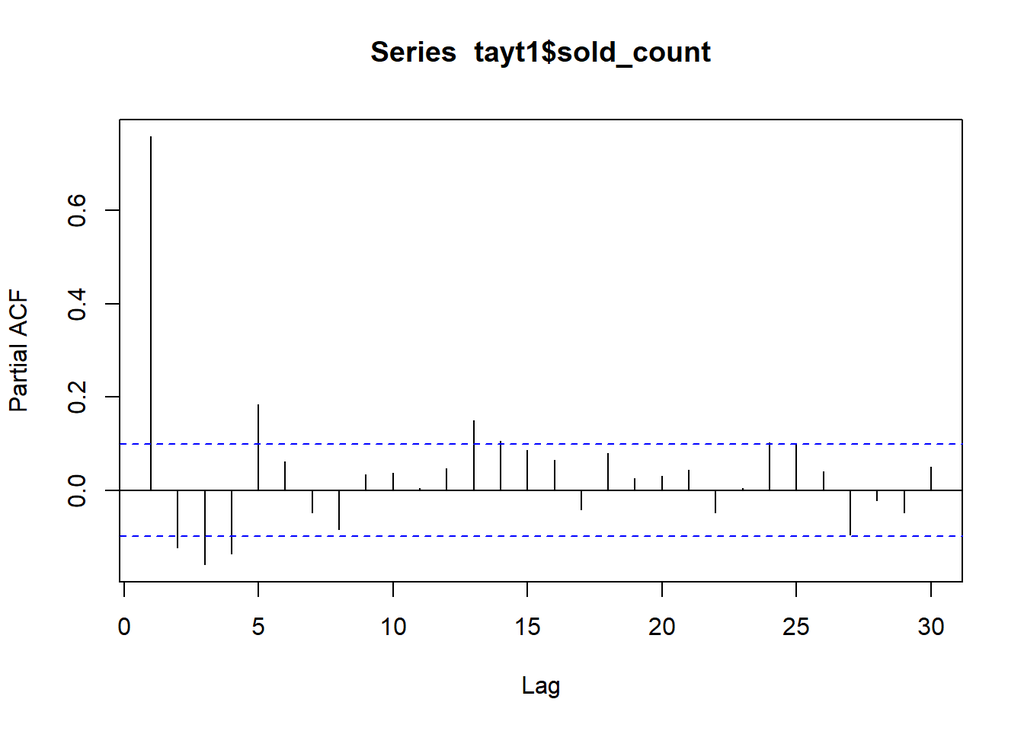

As we can see the effect of previous day is the most imported.

Decomposition with weekly seasonality and the result of KPSS test is below:

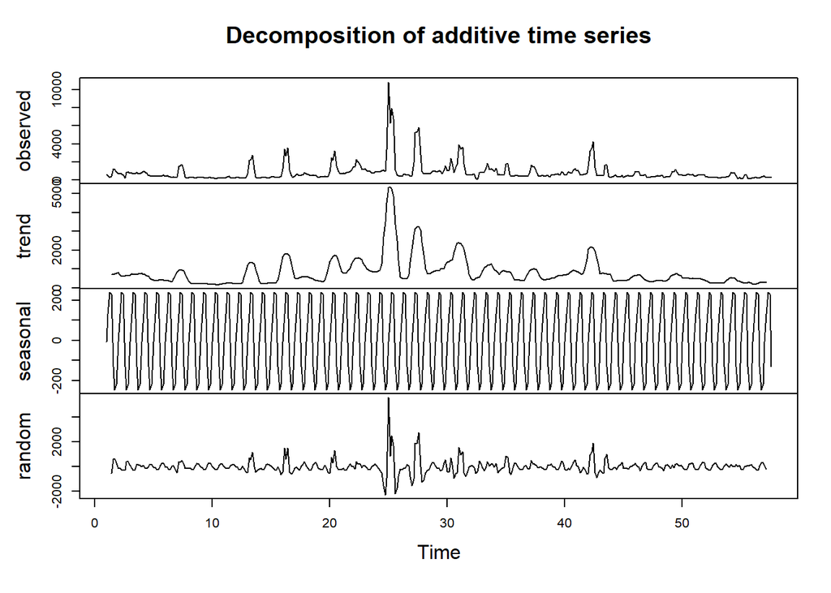

```
##
## #######################
## # KPSS Unit Root Test #
## #######################
##
## Test is of type: mu with 5 lags.
##
## Value of test-statistic is: 0.0064
##
## Critical value for a significance level of:
##                 10pct  5pct 2.5pct  1pct
## critical values 0.347 0.463  0.574 0.739
```

Decomposition for monthly seasonality and the result of KPSS test is below.

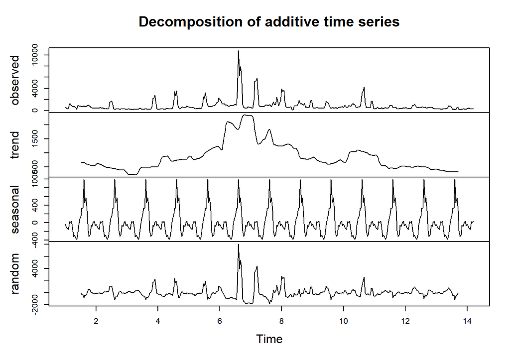

```
##
## #######################
## # KPSS Unit Root Test #
## #######################
##
## Test is of type: mu with 5 lags.
##
## Value of test-statistic is: 0.008
##
## Critical value for a significance level of:
##                 10pct  5pct 2.5pct  1pct
## critical values 0.347 0.463  0.574 0.739
```

Both seasonality levels proved that our random component is stationary. However, for the sake of simplicity we will move on with weekly seasonality.

###Bluetooth Headphone

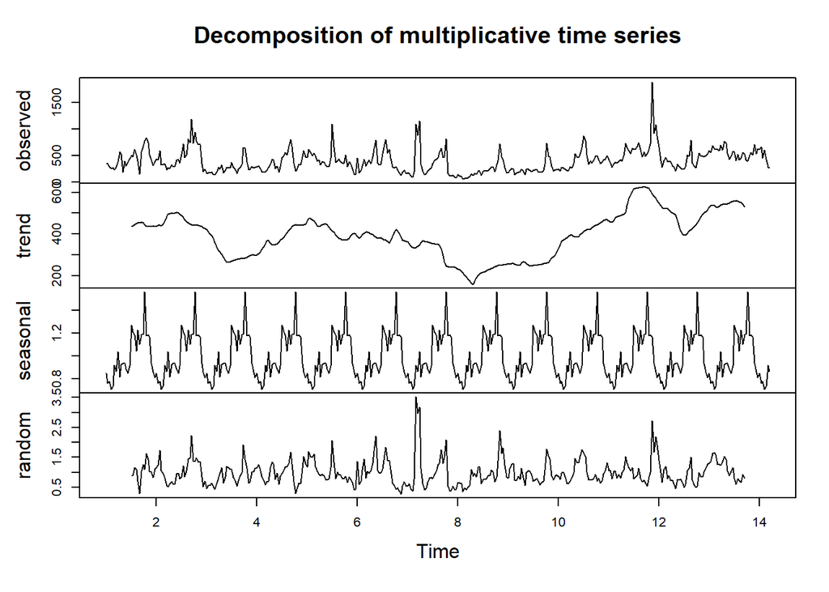

```
## [1] 0.9244332
```

As it can be seen, zero mean assumption does not hold. Additionally, the variance does not seem constant.

```
##
## #######################
## # KPSS Unit Root Test #
## #######################
##
## Test is of type: mu with 5 lags.
##
## Value of test-statistic is: 0.023
##
## Critical value for a significance level of:
##                 10pct  5pct 2.5pct  1pct
## critical values 0.347 0.463  0.574 0.739
```

```
##
## #######################
## # KPSS Unit Root Test #
## #######################
##
## Test is of type: mu with 5 lags.
##
## Value of test-statistic is: 0.0412
##
## Critical value for a significance level of:
##                 10pct  5pct 2.5pct  1pct
## critical values 0.347 0.463  0.574 0.739
```

### Upright Vacuum Cleaner

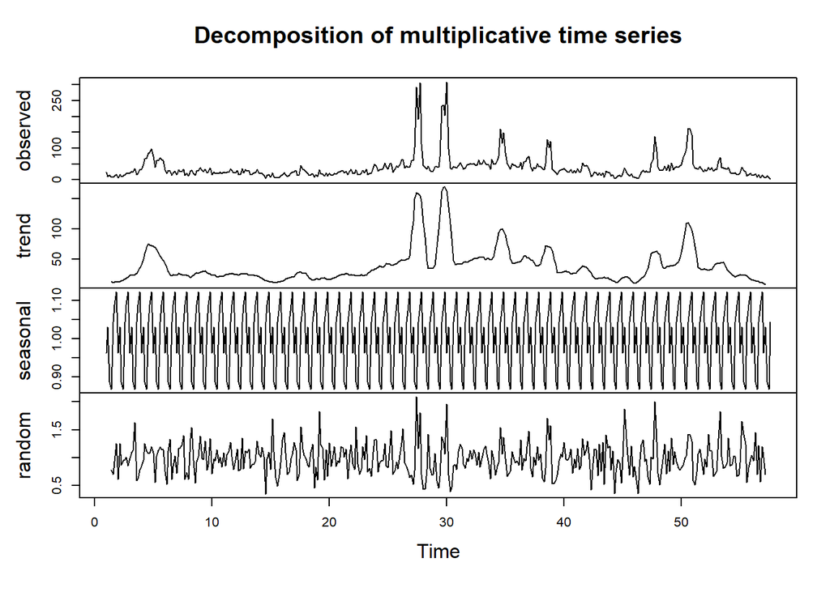

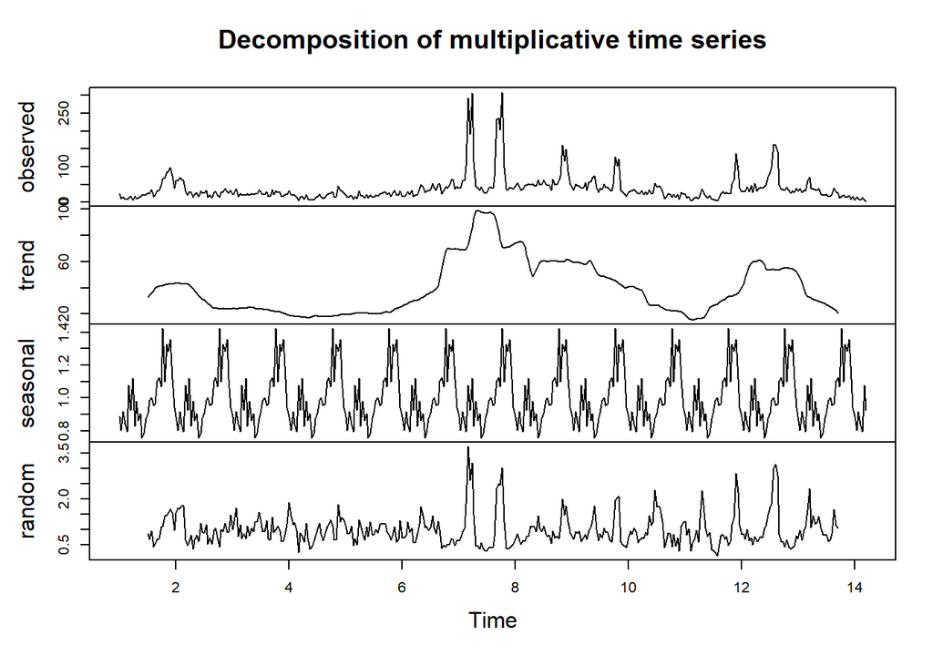

```
##
## #######################
## # KPSS Unit Root Test #
## #######################
##
## Test is of type: mu with 5 lags.
##
## Value of test-statistic is: 0.0585
##
## Critical value for a significance level of:
##                 10pct  5pct 2.5pct  1pct
## critical values 0.347 0.463  0.574 0.739
```

```
##
## #######################
## # KPSS Unit Root Test #
## #######################
##
## Test is of type: mu with 5 lags.
##
## Value of test-statistic is: 0.0188
##
## Critical value for a significance level of:
##                 10pct  5pct 2.5pct  1pct
## critical values 0.347 0.463  0.574 0.739
```

Both of them are significant, but weekly decomposition was preferred.

### Cleanser

Here is the plot of the Cleanser and the ACF, PACF plots of it:

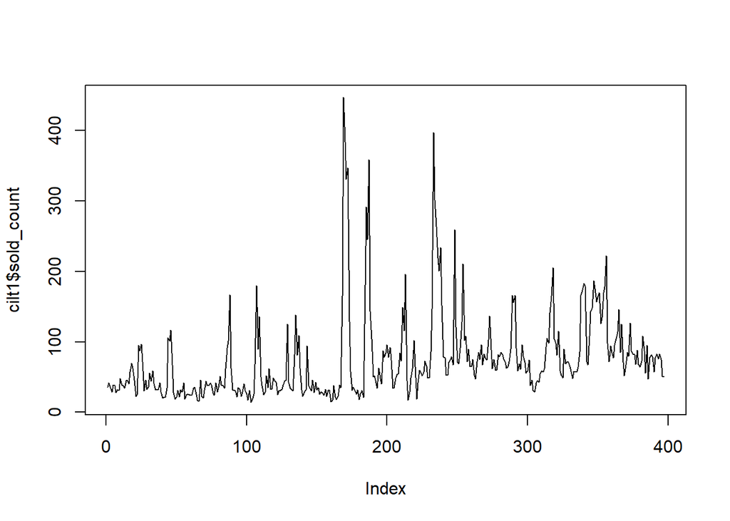

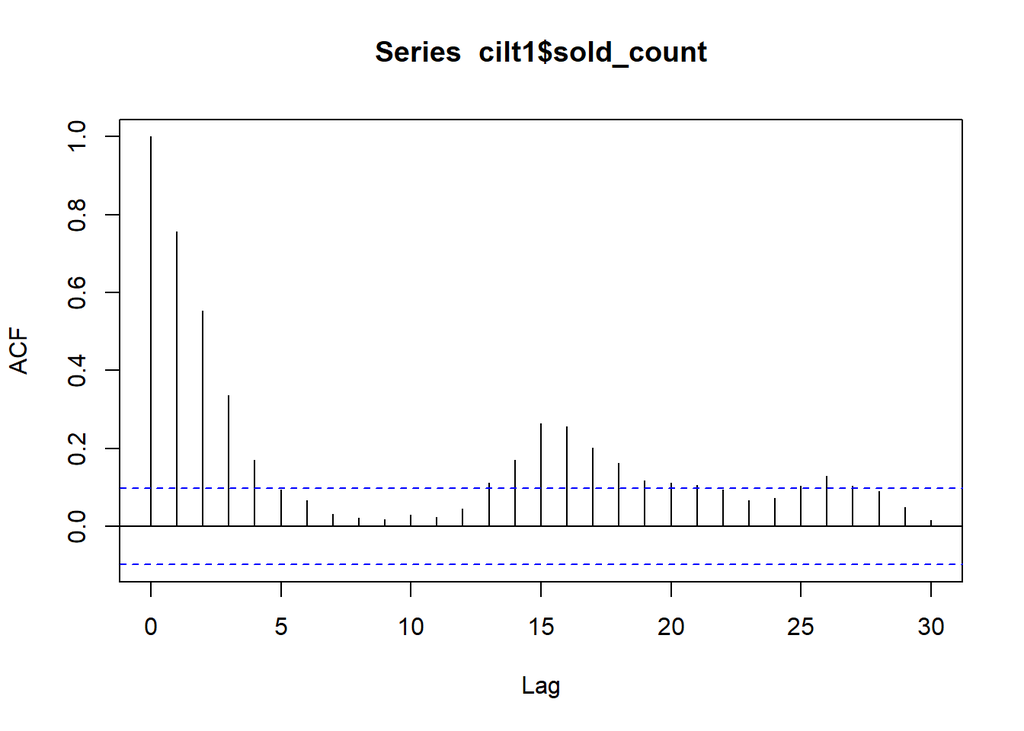

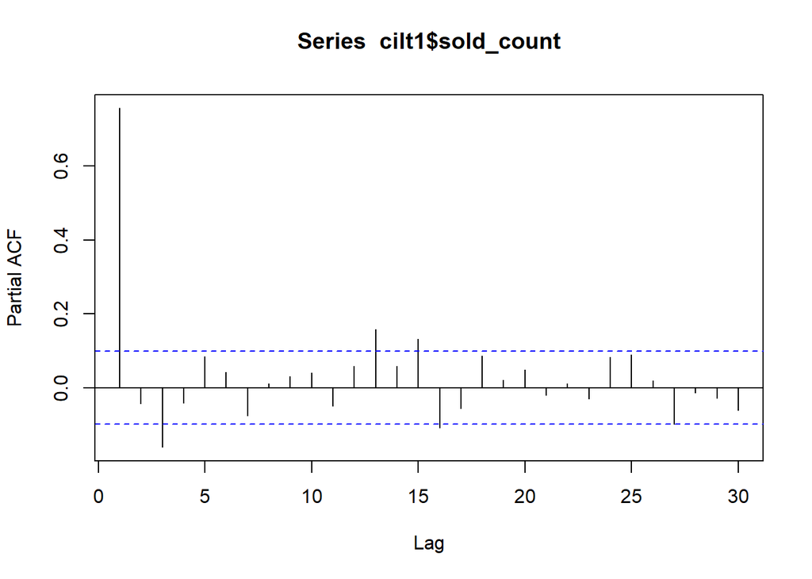

Decomposition with weekly seasonality and the result of KPSS test is below:

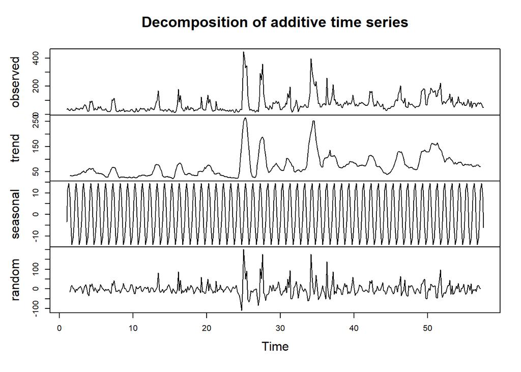

```
##
## #######################
## # KPSS Unit Root Test #
## #######################
##
## Test is of type: mu with 5 lags.
##
## Value of test-statistic is: 0.0063
##
## Critical value for a significance level of:
##                 10pct  5pct 2.5pct  1pct
## critical values 0.347 0.463  0.574 0.739
```

Decomposition with monthly seasonality and the result of KPSS test is below:

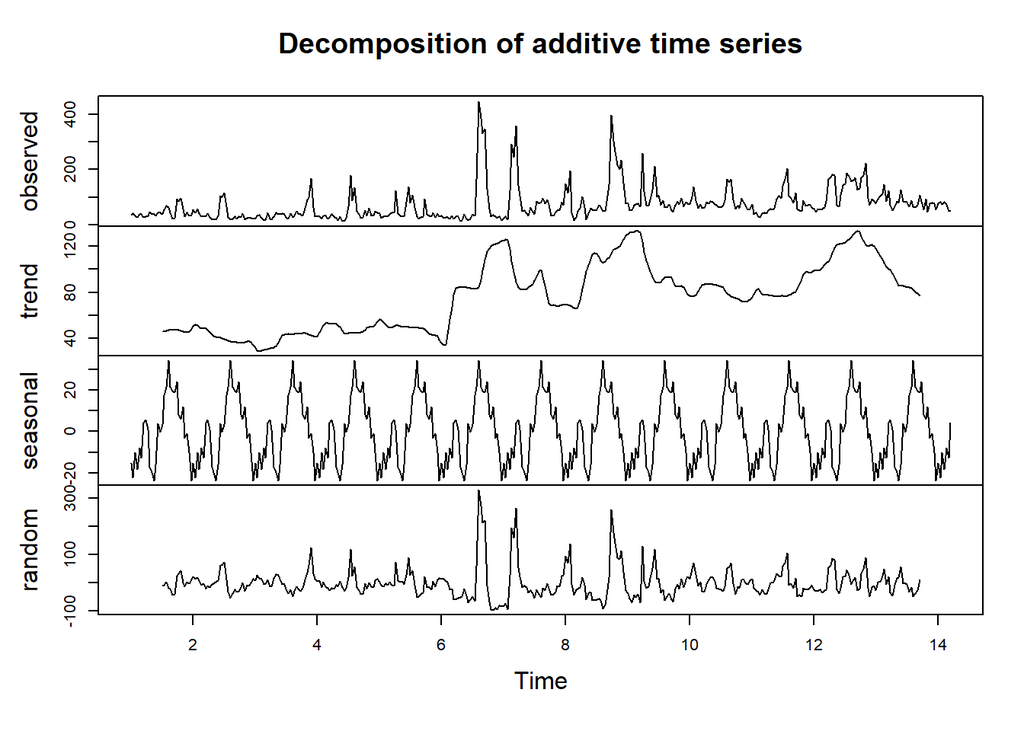

```
##
## #######################
## # KPSS Unit Root Test #
## #######################
##
## Test is of type: mu with 5 lags.
##
## Value of test-statistic is: 0.0081
##
## Critical value for a significance level of:
##                 10pct  5pct 2.5pct  1pct
## critical values 0.347 0.463  0.574 0.739
```

Due to lower value of the KPSS test of weekly seasonailty level, we will continue with weekly seasonality.

### Wet Wipes

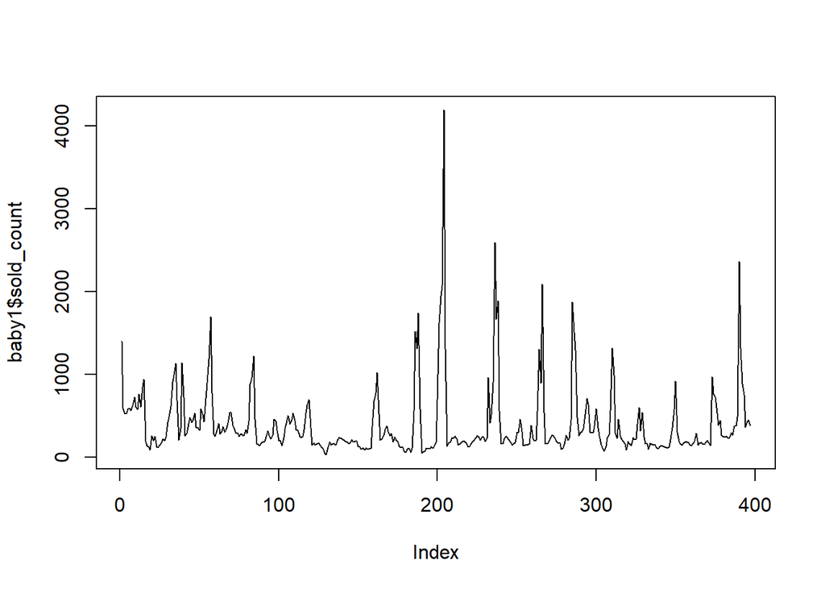

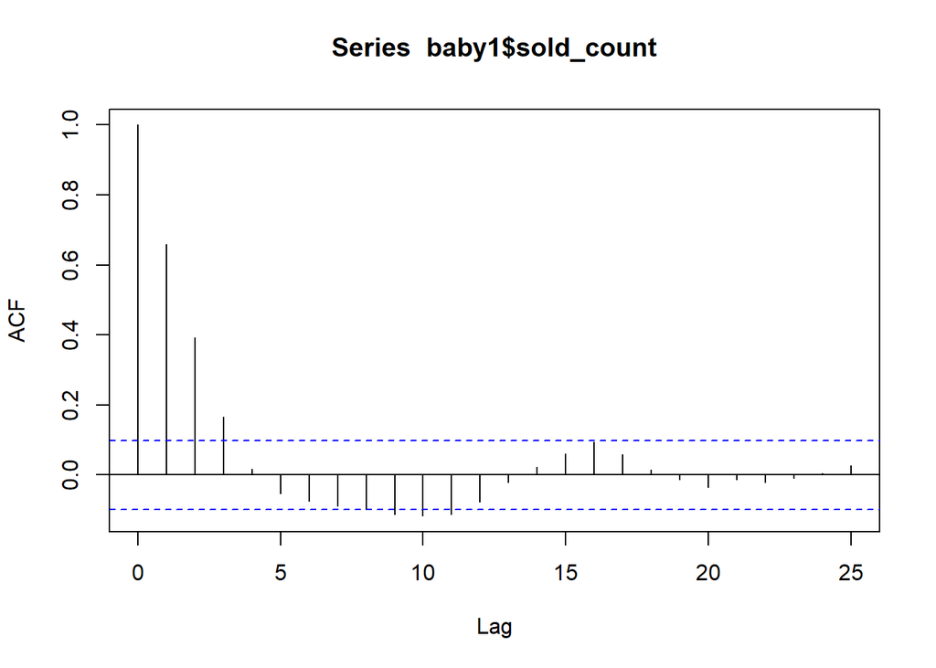

Decomposition with weekly seasonality and the result of KPSS test is below:

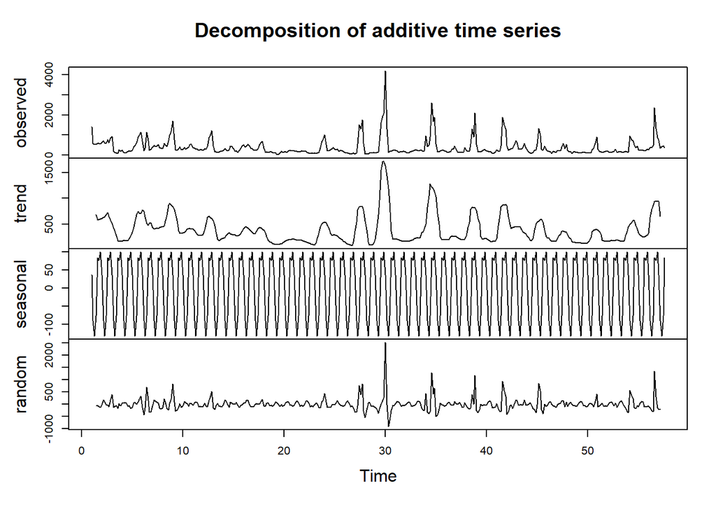

```
##
## #######################
## # KPSS Unit Root Test #
## #######################
##
## Test is of type: mu with 5 lags.
##
## Value of test-statistic is: 0.0073
##
## Critical value for a significance level of:
##                 10pct  5pct 2.5pct  1pct
## critical values 0.347 0.463  0.574 0.739
```

Decomposition with monthly seasonality and the result of KPSS test is below:

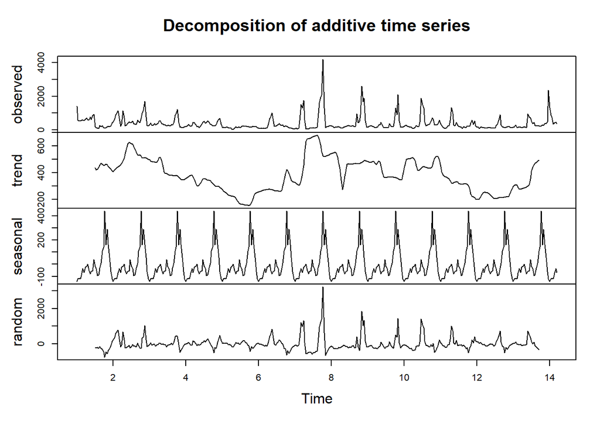

```
##
## #######################
## # KPSS Unit Root Test #
## #######################
##
## Test is of type: mu with 5 lags.
##
## Value of test-statistic is: 0.0193
##
## Critical value for a significance level of:
##                 10pct  5pct 2.5pct  1pct
## critical values 0.347 0.463  0.574 0.739
```

Weekly level’s critical KPSS value is smaller than monthly level. So, weekly seasonality is used.

### Electric Toothbrush

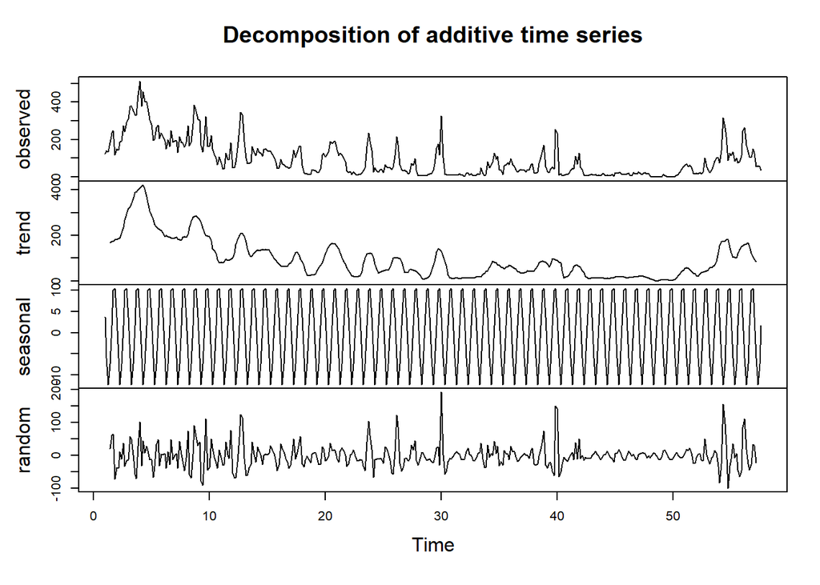

```
##
## #######################
## # KPSS Unit Root Test #
## #######################
##
## Test is of type: mu with 5 lags.
##
## Value of test-statistic is: 0.0103
##
## Critical value for a significance level of:
##                 10pct  5pct 2.5pct  1pct
## critical values 0.347 0.463  0.574 0.739
```

```
##
## #######################
## # KPSS Unit Root Test #
## #######################
##
## Test is of type: mu with 5 lags.
##
## Value of test-statistic is: 0.0444
##
## Critical value for a significance level of:
##                 10pct  5pct 2.5pct  1pct
## critical values 0.347 0.463  0.574 0.739
```

Weekly decomposition seems sufficient enough, and intuitively, choosing weekly basis seemed more logical.

## Question 2

### Bikini Top 1

After trying various ARIMA models along with the auto.arima function, we decided to go with what auro.arima suggested as its residuals seemed to fit more to our assumptions.

```
## Series: random_b1
## ARIMA(5,0,0)(2,0,0)[7] with zero mean
##
## Coefficients:
##           ar1      ar2      ar3      ar4      ar5     sar1     sar2
##       -0.0005  -0.4080  -0.3636  -0.1784  -0.4341  -0.2754  -0.0835
## s.e.   0.0468   0.0474   0.0471   0.0486   0.0532   0.0630   0.0606
##
## sigma^2 estimated as 108.6:  log likelihood=-1494.8
## AIC=3005.6   AICc=3005.97   BIC=3037.49
```

In the above model, the AIC value is 3005.6, and the BIC value is 3037.49. The actual-fitted plot and our predictions using this model can be found below.

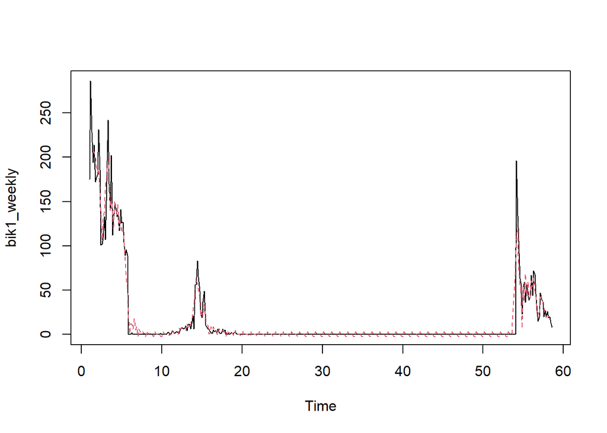

```
## Time Series:
## Start = c(57, 6)
## End = c(58, 5)
## Frequency = 7
##              random random_fitted actual modelgen forecasted
## 57.71429  1.0455284    -3.3924479     27 22.56202   29.70751
## 57.85714 -0.3028426    -1.4810428     20 18.82180   26.35520
## 58.00000  8.1282351    -0.3065476     26 17.56522   29.67594
## 58.14286 -4.4632436    -2.5366112     19 20.92663   30.82668
## 58.28571         NA            NA     20       NA   28.04511
## 58.42857         NA            NA     14       NA   20.09593
## 58.57143         NA            NA      8       NA   17.82034
```

### Bikini Top 2

After trying various ARIMA models analysing the ACF and PACF plots and auto.arima function, we decided to go with ARIMA(3,0,4), since its residuals were better than other models on the basis of our assumptions.

```
##
## Call:
## arima(x = random_b2, order = c(3, 0, 4))
##
## Coefficients:
##          ar1     ar2      ar3      ma1      ma2      ma3     ma4  intercept
##       0.6009  0.0846  -0.1789  -0.7396  -0.5224  -0.2947  0.5567    -0.0073
## s.e.  0.0900  0.1008   0.0749   0.0796   0.0931   0.0765  0.0628     0.0020
##
## sigma^2 estimated as 22.45:  log likelihood = -1167.12,  aic = 2352.23
```

```
## [1] 2387.952
```

As can be seen above, the AIC value is 2352.23, the BIC value is 2387.952. The actual-fitted plot and our predictions using this model can be found below.

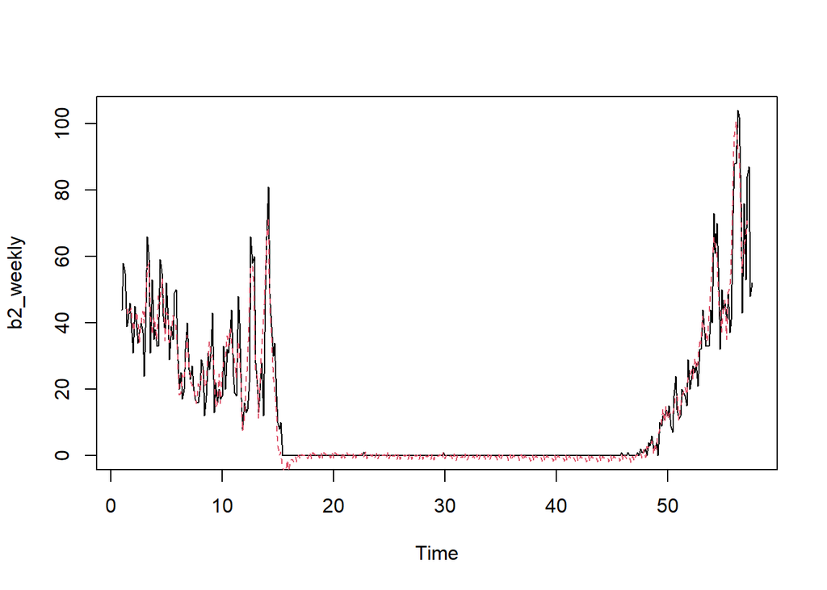

```
## Time Series:
## Start = c(57, 6)
## End = c(58, 5)
## Frequency = 7
##          random random_fitted actual modelgen forecasted
## 57.71429     NA            NA     NA       NA   81.51306
## 57.85714     NA            NA     NA       NA   83.83174
## 58.00000     NA            NA     NA       NA   76.74554
## 58.14286     NA            NA     NA       NA   78.09802
## 58.28571     NA            NA     NA       NA   74.16059
## 58.42857     NA            NA     NA       NA   67.03556
## 58.57143     NA            NA     NA       NA   62.89593
```

### Coat

We chose ARIMA(2,0,3) to analyse this product because of the fit of its residuals, which is better than the residuals of other models, including the model of auto.arima

```
##
## Call:
## arima(x = random_cs, order = c(2, 0, 3))
##
## Coefficients:
##          ar1      ar2      ma1     ma2     ma3  intercept
##       1.0816  -0.5283  -1.6126  0.4310  0.1816     -2e-04
## s.e.  0.0635   0.0625   0.0728  0.1315  0.0702      4e-04
##
## sigma^2 estimated as 3.767:  log likelihood = -818.42,  aic = 1650.83
```

```
## [1] 1678.615
```

The above model’s AIC value is 1650.83, whereas its BIC value is 1678.615. The actual-fitted plot and our predictions using this model can be found below.

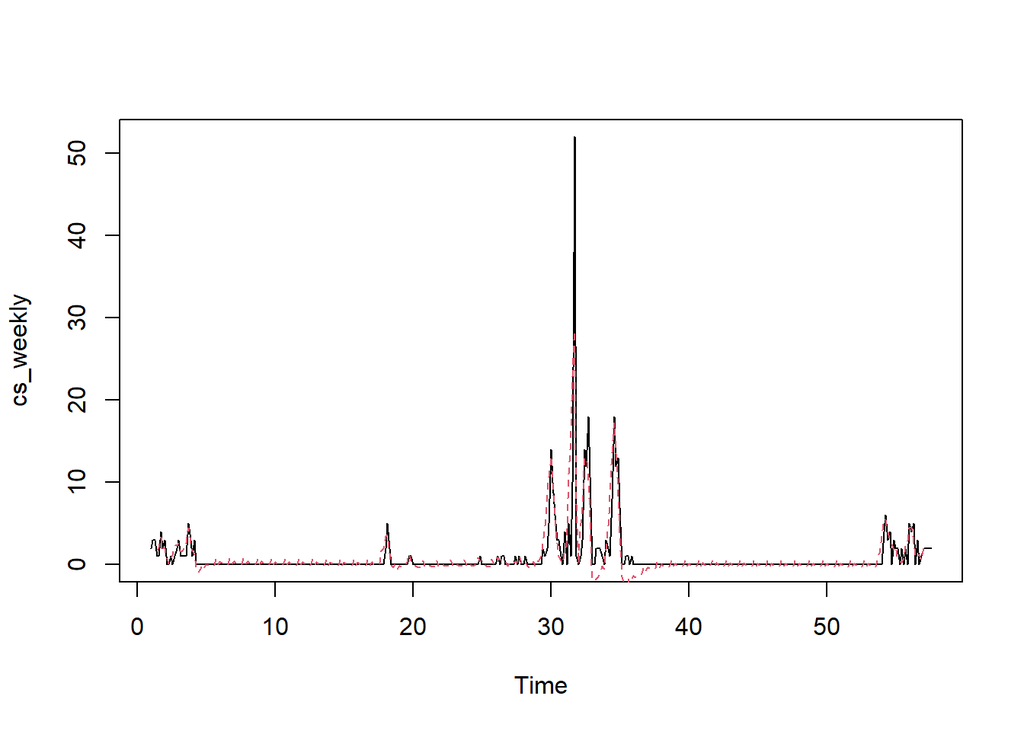

```
## Time Series:
## Start = c(57, 6)
## End = c(58, 5)
## Frequency = 7
##          random random_fitted actual modelgen forecasted
## 57.71429     NA            NA     NA       NA   3.327129
## 57.85714     NA            NA     NA       NA   2.412630
## 58.00000     NA            NA     NA       NA   2.084235
## 58.14286     NA            NA     NA       NA   1.606537
## 58.28571     NA            NA     NA       NA   1.111824
## 58.42857     NA            NA     NA       NA   1.539104
## 58.57143     NA            NA     NA       NA   1.682127
```

## Tights

To find a better arima model, we need to check the ACF and PACF plots.

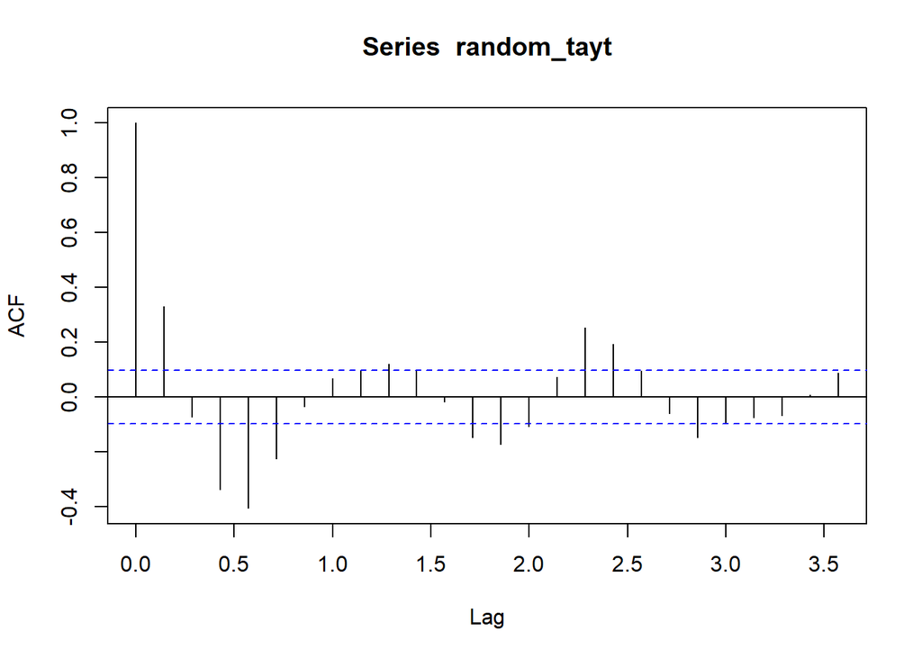

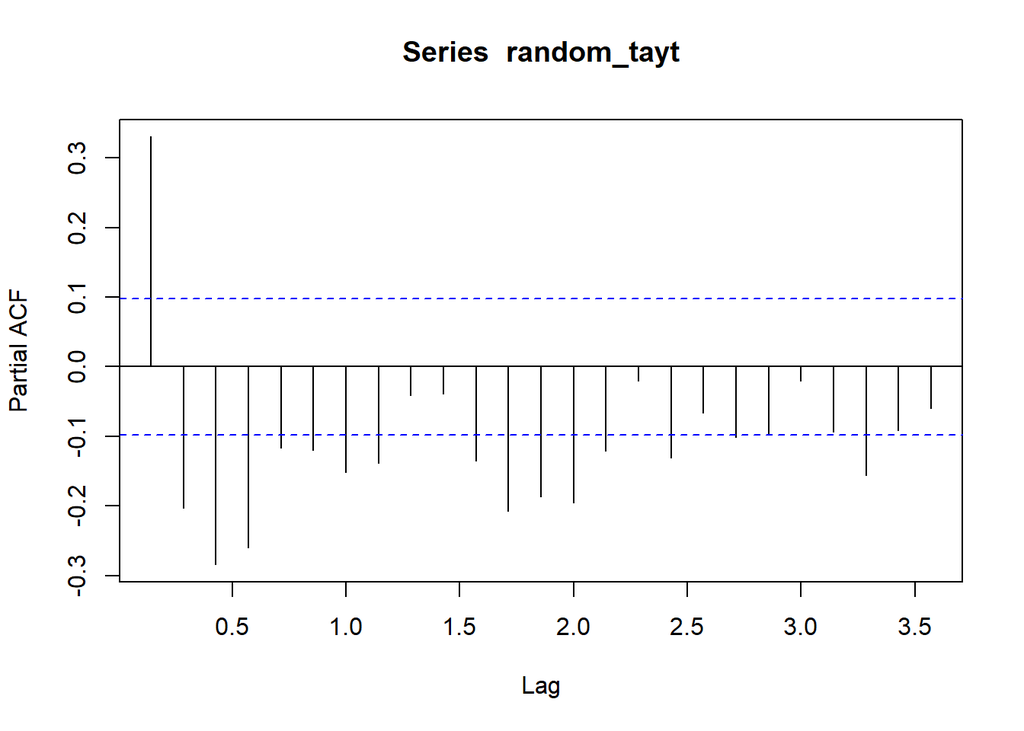

Negative PACF values is a sign of autoregressive behavior. After trying possible ARIMA models and evaluated their AIC values, we come up with (2,0,2) model. Here its table:

```
##
## Call:
## arima(x = random_tayt, order = c(2, 0, 2))
##
## Coefficients:
##          ar1      ar2      ma1     ma2  intercept
##       1.3554  -0.7222  -1.3678  0.3678     0.0620
## s.e.  0.0647   0.0474   0.0975  0.0973     0.3342
##
## sigma^2 estimated as 186041:  log likelihood = -2930.17,  aic = 5872.33
```

Actual vs fitted plot is below:

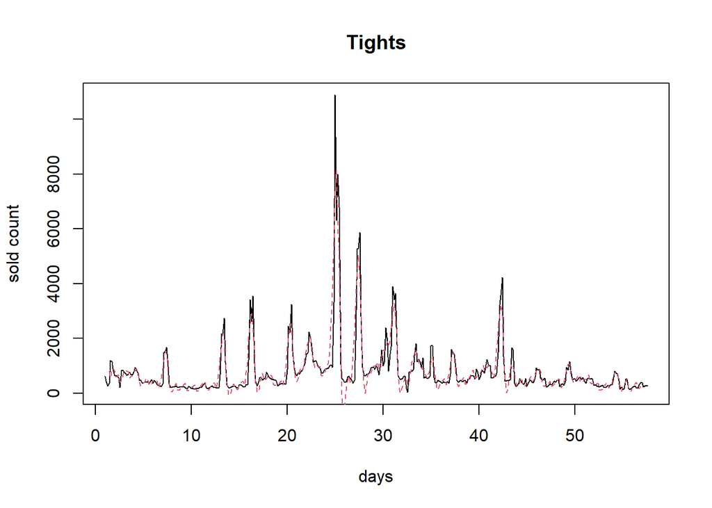

## Bluetooth Headphone

[figure not shown]

```
## [1] 3746.613
```

```
## [1] 3830.539
```

PACF plot has negative values. This is a sign of autoregrresive model. After trying, auto.arima() function seemed working good enough.

## Upright Vacuum Cleaner

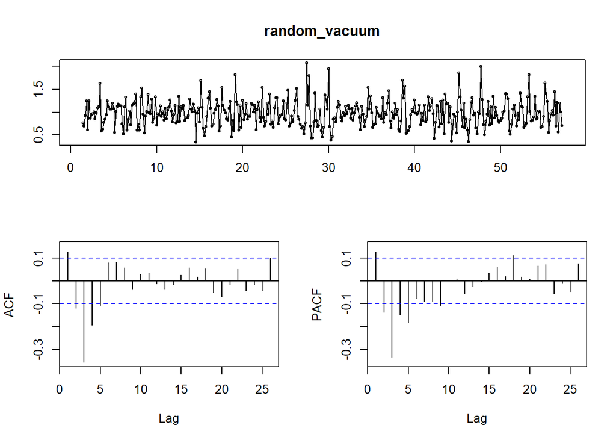

auto.arima() was used.

## Cleanser

Here is the ACF and PACF plots of the random term:

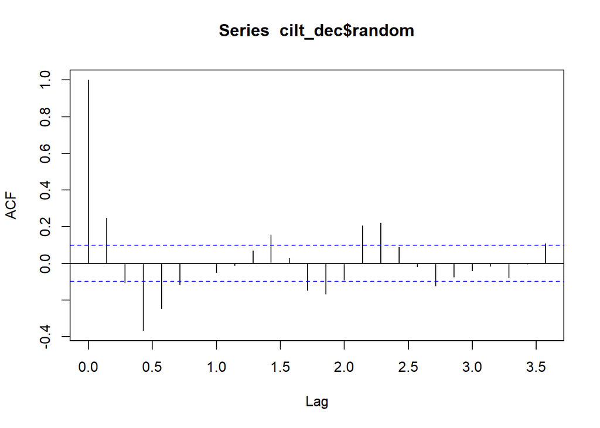

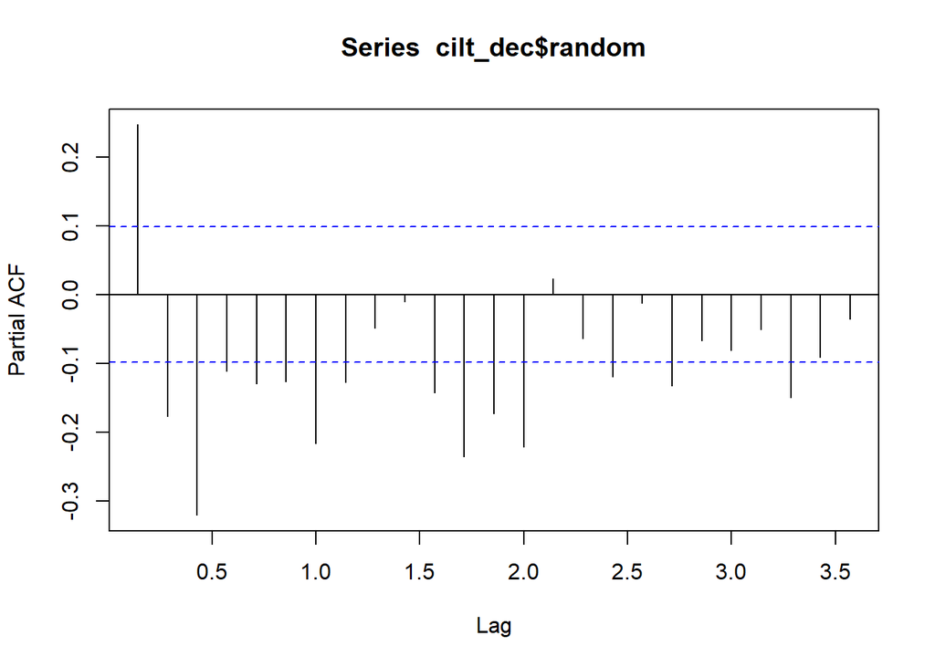

After evaluating the plots above and using auto arima function we used the model (3,0,2),(0,0,1)

```
##
## Call:
## arima(x = cilt_dec$random, order = c(3, 0, 2), seasonal = c(0, 0, 1))
##
## Coefficients:
##          ar1      ar2      ar3      ma1      ma2     sma1  intercept
##       0.7833  -0.1805  -0.2640  -0.8794  -0.1206  -0.2493     0.0039
## s.e.  0.3276   0.3307   0.1631   0.3464   0.3463   0.0596     0.0146
##
## sigma^2 estimated as 629.5:  log likelihood = -1818.33,  aic = 3652.65
```

Here is actual vs fitted plot:

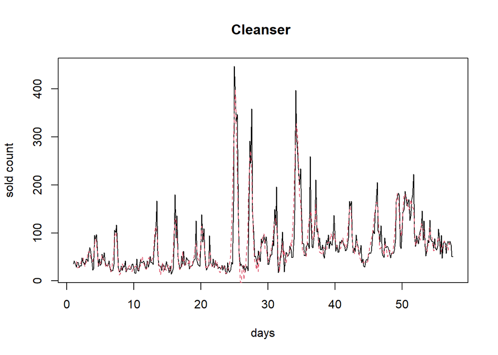

```
## integer(0)
```

## Wet Wipes

Here is the ACF and PACF plots of the random term:

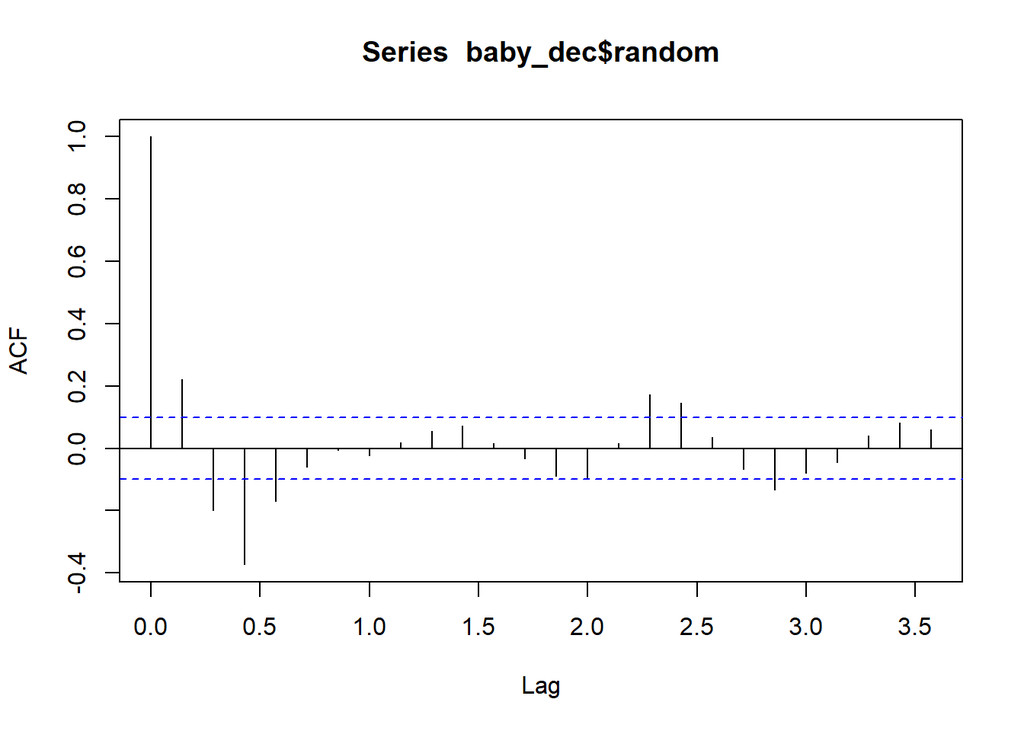

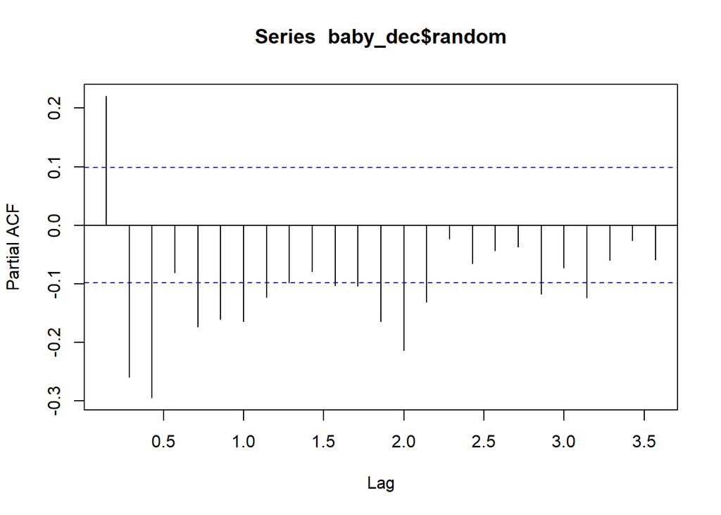

Negative values indicates autoregressive behaviour. The model that has best AIC value is choosen. Here is the table of it.

```
##
## Call:
## arima(x = baby_dec$random, order = c(3, 0, 1))
##
## Coefficients:
##          ar1      ar2      ar3      ma1  intercept
##       0.9124  -0.3739  -0.1053  -1.0000    -0.0461
## s.e.  0.0503   0.0655   0.0503   0.0065     0.1641
##
## sigma^2 estimated as 43177:  log likelihood = -2644.35,  aic = 5300.71
```

Here is actual vs fitted plot:

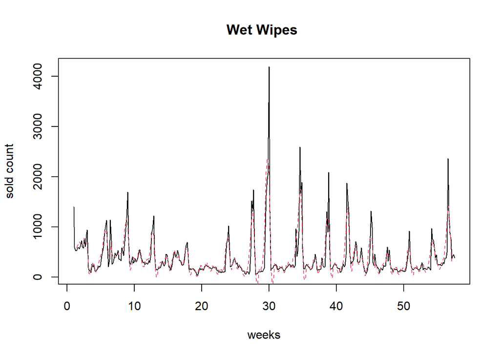

```
## integer(0)
```

## Electric Toothbrush

auto.arima() was used.

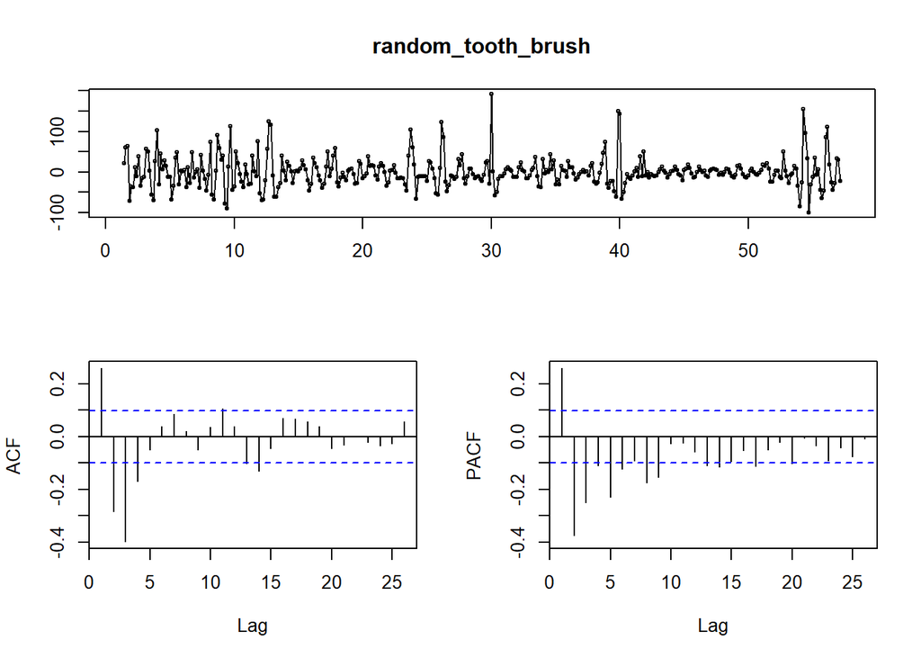

## Question 3

### Bikini Top 1

After trying every variable available as a regressor, we decided to go with the above group since they gave the biggest Adjusted R-squared value.

```
##
## Call:
## lm(formula = random_b1 ~ bikinitop1$favoured_count + bikinitop1$category_sold +
##     bikinitop1$price)
##
## Residuals:
##     Min      1Q  Median      3Q     Max
## -46.539  -8.561   0.989   6.120 110.308
##
## Coefficients:
##                             Estimate Std. Error t value Pr(>|t|)
## (Intercept)               -4.800e+00  3.112e+00  -1.542   0.1258
## bikinitop1$favoured_count  4.985e-03  2.389e-03   2.087   0.0392 *
## bikinitop1$category_sold   1.167e-03  8.697e-04   1.342   0.1824
## bikinitop1$price          -6.843e-10  1.345e-09  -0.509   0.6118
## ---
## Signif. codes:  0 '***' 0.001 '**' 0.01 '*' 0.05 '.' 0.1 ' ' 1
##
## Residual standard error: 19.98 on 113 degrees of freedom
##   (287 observations deleted due to missingness)
## Multiple R-squared:  0.06502,    Adjusted R-squared:  0.0402
## F-statistic:  2.62 on 3 and 113 DF,  p-value: 0.05429
```

### Bikini Top 2

After trying our variables as regressors, we chose the combination below due to their relatively high Adjusted R-squared value.

```
##
## Call:
## lm(formula = random_b2 ~ bikinitop2$visit_count + bikinitop2$price +
##     bikinitop2$favoured_count)
##
## Residuals:
##     Min      1Q  Median      3Q     Max
## -33.674  -4.776   0.041   5.448  25.424
##
## Coefficients:
##                             Estimate Std. Error t value Pr(>|t|)
## (Intercept)               -3.108e+00  1.183e+00  -2.628  0.00939 **
## bikinitop2$visit_count     1.034e-03  8.890e-04   1.163  0.24632
## bikinitop2$price           6.177e-10  4.105e-10   1.505  0.13432
## bikinitop2$favoured_count  1.542e-03  5.496e-03   0.281  0.77942
## ---
## Signif. codes:  0 '***' 0.001 '**' 0.01 '*' 0.05 '.' 0.1 ' ' 1
##
## Residual standard error: 9.536 on 165 degrees of freedom
##   (228 observations deleted due to missingness)
## Multiple R-squared:  0.08066,    Adjusted R-squared:  0.06394
## F-statistic: 4.825 on 3 and 165 DF,  p-value: 0.003019
```

### Coat

After analysing our variables, the only variable that was somewhat significant and gave a statistically significant regression was used.

```
##
## Call:
## lm(formula = random_cs ~ coat$category_sold)
##
## Residuals:
##     Min      1Q  Median      3Q     Max
## -11.386  -0.355   0.196   0.345  40.827
##
## Coefficients:
##                      Estimate Std. Error t value Pr(>|t|)
## (Intercept)        -0.1258198  0.1468686  -0.857   0.3921
## coat$category_sold  0.0007275  0.0003369   2.159   0.0314 *
## ---
## Signif. codes:  0 '***' 0.001 '**' 0.01 '*' 0.05 '.' 0.1 ' ' 1
##
## Residual standard error: 2.682 on 389 degrees of freedom
##   (6 observations deleted due to missingness)
## Multiple R-squared:  0.01184,    Adjusted R-squared:  0.009302
## F-statistic: 4.662 on 1 and 389 DF,  p-value: 0.03145
```

The above regression is statistically significant, although the Adjusted R-squared value is really low. The significance level of the category_sold variable is only 0.05, though.

### Tights

As regressor we tried basket cont, price and category sold data, and then chect the AIC value for each of them. According to AIC value category sold data may improve our model.

```
##
## Call:
## arima(x = random_tayt, order = c(2, 0, 2), xreg = tayt1$category_sold)
##
## Coefficients:
##          ar1     ar2     ma1     ma2  intercept  tayt1$category_sold
##       0.7688  0.0945  0.2231  0.0925  -941.2980               0.4160
## s.e.  0.3688  0.3325  0.3594  0.0682   168.4793               0.0159
##
## sigma^2 estimated as 117963:  log likelihood = -2838.77,  aic = 5691.54
```

As we can see AIC value has improved compared to previous ARIMA model. Here is actual vs fitted plot:

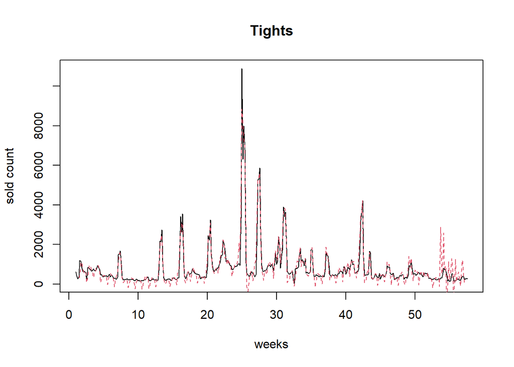

### Cleanser

```
##
## Call:
## arima(x = cilt_dec$random, order = c(3, 0, 2), seasonal = c(0, 0, 1), xreg = cilt1$category_sold)
##
## Coefficients:
##          ar1      ar2      ar3      ma1      ma2     sma1  intercept
##       0.7869  -0.1846  -0.2619  -0.8838  -0.1162  -0.2501    -0.0361
## s.e.  0.3293   0.3324   0.1643   0.3481   0.3481   0.0597        NaN
##       cilt1$category_sold
##                     1e-04
## s.e.                  NaN
##
## sigma^2 estimated as 628.5:  log likelihood = -1818.04,  aic = 3654.08
```

Actual vs fitted plot:

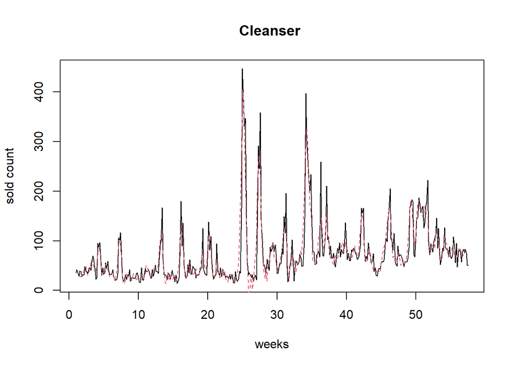

### Wet Wipes

According to AIC values category sold data may improve our model.

```
##
## Call:
## arima(x = baby_dec$random, order = c(3, 0, 1), xreg = baby1$category_sold)
##
## Coefficients:
##          ar1     ar2      ar3     ma1  intercept  baby1$category_sold
##       0.1023  0.5310  -0.1697  0.7203  -366.7299               0.1998
## s.e.  0.1427  0.1011   0.0524  0.1281    34.0202               0.0105
##
## sigma^2 estimated as 30180:  log likelihood = -2571.8,  aic = 5157.61
```

Actual vs fitted plot:

[figure not shown]

### Eletcric Toothbrush

Obviously, we expected the price of the products to be effective on how many they sell, basically a significant demand function where an increase in price would decrease the demand and therefore, the sales. In addition, we would expect our other variables to be more significant than they are. However, probably because of the nature of the data, we did not get the results we hoped. That is, since many variables were only NA’s especially when the products did not sell, which happened a lot for some of the products, we think we could not obtain the actual effects of the variables on the sales. Therefore, our regressions may reflect less than we hoped.

## Question 4

### Bikini Top 1

After grouping the regressors that will be used for the prediction with the arimax model, we built our arimax model.

```
## Series: random_b1
## Regression with ARIMA(0,0,0) errors
##
## Coefficients:
##       intercept   xreg1   xreg2  xreg3
##         -4.8001  0.0050  0.0012  0e+00
## s.e.     3.0587  0.0023  0.0009  1e-04
##
## sigma^2 estimated as 114.5:  log likelihood=-514.38
## AIC=1038.76   AICc=1038.91   BIC=1058.69
```

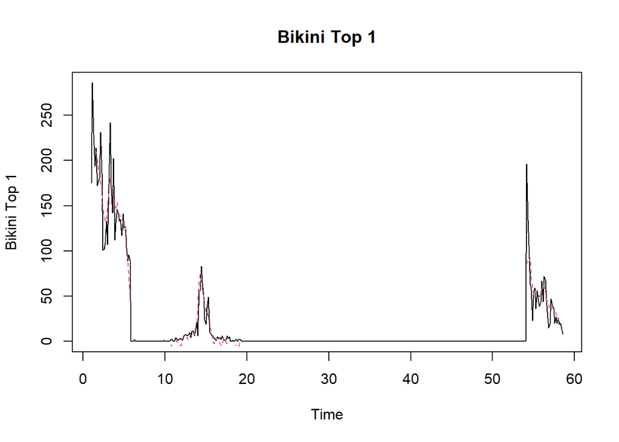

```
## Time Series:
## Start = c(57, 6)
## End = c(58, 5)
## Frequency = 7
##              random random_fitted actual modelgen forecasted
## 57.71429  1.0455284      4.747016     27 30.70149   33.92450
## 57.85714 -0.3028426      8.258197     20 28.56104   31.85909
## 58.00000  8.1282351      5.191662     26 23.06343   31.53273
## 58.14286 -4.4632436      5.541456     19 29.00470   34.29241
## 58.28571         NA            NA     20       NA   32.98009
## 58.42857         NA            NA     14       NA   29.67633
## 58.57143         NA            NA      8       NA   23.23385
```

### Bikini Top 2

After grouping the regressors that will be used for predicting with the arimax model, we obtained the arimax model.

```
##
## Call:
## arima(x = random_b2, order = c(2, 0, 5), xreg = regb2)
##
## Coefficients:
##           ar1     ar2     ma1      ma2      ma3     ma4     ma5  intercept
##       -0.3043  0.6011  0.0424  -1.3411  -0.7543  0.3839  0.6760    -0.0424
## s.e.   0.1831  0.1476  0.1756   0.1707   0.1364  0.0771  0.1119     0.0316
##       regb21  regb22  regb23
##       -2e-04       0  0.0015
## s.e.     NaN     NaN  0.0003
##
## sigma^2 estimated as 45.94:  log likelihood = -576.16,  aic = 1176.31
```

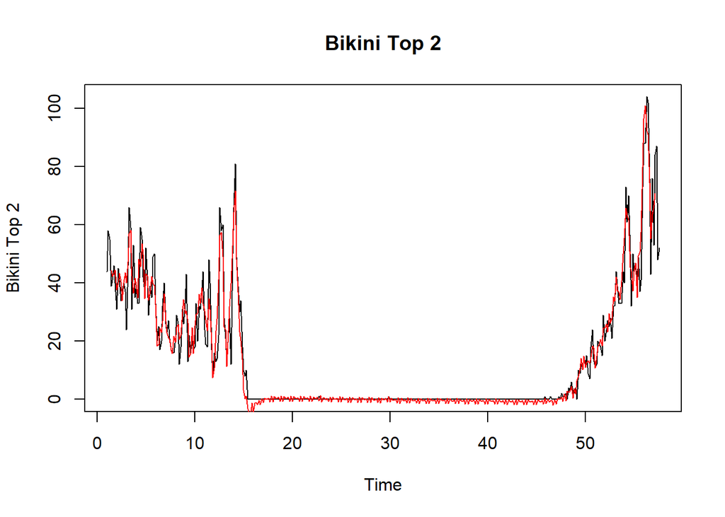

```
## Time Series:
## Start = c(57, 6)
## End = c(58, 5)
## Frequency = 7
##          random random_fitted actual modelgen forecasted
## 57.71429     NA            NA     NA       NA   83.39691
## 57.85714     NA            NA     NA       NA   82.06245
## 58.00000     NA            NA     NA       NA   78.15333
## 58.14286     NA            NA     NA       NA   76.70362
## 58.28571     NA            NA     NA       NA   75.46689
## 58.42857     NA            NA     NA       NA   65.78054
## 58.57143     NA            NA     NA       NA   63.97432
```

### Coat

After getting the regressor that will be used for the predictions with the arimax model, we obtained the arimax model.

```
##  [1] 1080 1039  770  970 1098 1024  844 1150 1161  900
```

```
##
## Call:
## arima(x = random_cs, order = c(2, 0, 3), xreg = coat$category_sold)
##
## Coefficients:
##          ar1      ar2      ma1     ma2     ma3  intercept  coat$category_sold
##       1.0825  -0.5273  -1.6155  0.4314  0.1841    -0.0013                   0
## s.e.  0.0634   0.0626   0.0725  0.1316  0.0703        NaN                 NaN
##
## sigma^2 estimated as 3.758:  log likelihood = -817.99,  aic = 1651.98
```

The information criteria of the model improved again, the new AIC being 1651.98 and the new BIC being 1683.725. The actual-fitted plot of this model and the new predictions can be found below.

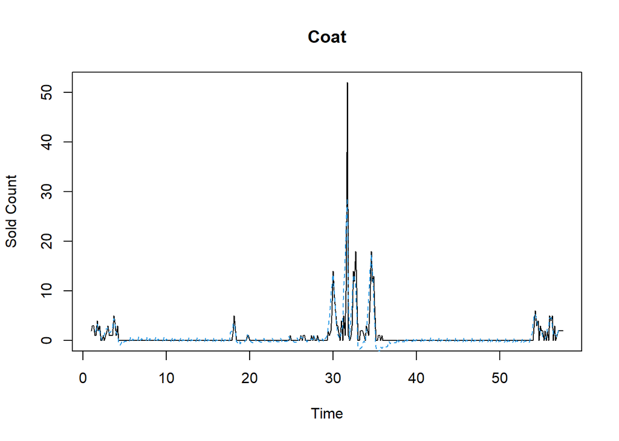

```
## Time Series:
## Start = c(57, 6)
## End = c(58, 5)
## Frequency = 7
##          random random_fitted actual modelgen forecasted
## 57.71429     NA            NA     NA       NA   3.331436
## 57.85714     NA            NA     NA       NA   2.435369
## 58.00000     NA            NA     NA       NA   2.108776
## 58.14286     NA            NA     NA       NA   1.623067
## 58.28571     NA            NA     NA       NA   1.122282
## 58.42857     NA            NA     NA       NA   1.543991
## 58.57143     NA            NA     NA       NA   1.683311
```

### Tights

Here we can see the table for the forecasted values:

```
## Time Series:
## Start = c(57, 2)
## End = c(58, 5)
## Frequency = 7
##             random randomfitted actual   modelgen forecasted seasonality trend
## 57.14286 -208.7198    -432.7679    224 -0.0481214         NA    130.7198   302
## 57.28571        NA           NA    269         NA   899.8881    238.7247    NA
## 57.42857        NA           NA    265         NA   783.2787    229.5693    NA
## 57.57143        NA           NA    264         NA   720.1024   -128.5124    NA
## 57.71429        NA           NA     NA         NA  1048.2982          NA    NA
## 57.85714        NA           NA     NA         NA  1830.6271          NA    NA
## 58.00000        NA           NA     NA         NA  1693.9735          NA    NA
## 58.14286        NA           NA     NA         NA  1043.1063          NA    NA
## 58.28571        NA           NA     NA         NA  1152.9497          NA    NA
## 58.42857        NA           NA     NA         NA  1096.3164          NA    NA
## 58.57143        NA           NA     NA         NA   923.9582          NA    NA
```

Here is the the plot which indicated actual, fitted and forecasted values:

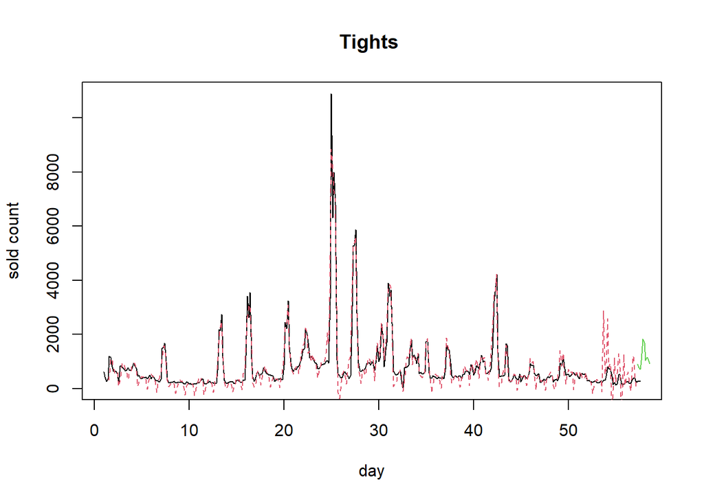

```
## integer(0)
```

### Bluetooth Headphone

Predictions with regressors can be found below.

```
## Time Series:
## Start = c(56, 2)
## End = c(58, 7)
## Frequency = 7
##          actual forecasted
## 56.14286    508         NA
## 56.28571    702         NA
## 56.42857    530         NA
## 56.57143    620         NA
## 56.71429    614         NA
## 56.85714    658         NA
## 57.00000    455         NA
## 57.14286    597         NA
## 57.28571    425         NA
## 57.42857    274         NA
## 57.57143    266   471.7337
## 57.71429     NA   471.8344
## 57.85714     NA   471.9916
## 58.00000     NA   471.9633
## 58.14286     NA   471.9388
## 58.28571     NA   471.8002
## 58.42857     NA   471.7045
## 58.57143     NA   471.7517
## 58.71429     NA   471.8512
## 58.85714     NA   471.9167
```

### Upright Vacuum Cleaner

Predictions with regressors can be found below.

```
## Time Series:
## Start = c(56, 7)
## End = c(59, 5)
## Frequency = 7
##             random random_fitted actual  modelgen forecasted
## 56.85714 1.1970473     0.9280502     14 10.853960         NA
## 57.00000 1.0100688     0.9531842     10  9.436825         NA
## 57.14286 0.7028386     1.0155429      6  8.669498         NA
## 57.28571        NA            NA     12        NA         NA
## 57.42857        NA            NA      7        NA         NA
## 57.57143        NA            NA      2        NA         NA
## 57.71429        NA            NA     NA        NA         NA
## 57.85714        NA            NA     NA        NA         NA
## 58.00000        NA            NA     NA        NA         NA
## 58.14286        NA            NA     NA        NA         NA
## 58.28571        NA            NA     NA        NA   7.655417
## 58.42857        NA            NA     NA        NA   7.206903
## 58.57143        NA            NA     NA        NA   8.332579
## 58.71429        NA            NA     NA        NA   8.581832
## 58.85714        NA            NA     NA        NA   8.904013
## 59.00000        NA            NA     NA        NA   7.766998
## 59.14286        NA            NA     NA        NA   8.423623
## 59.28571        NA            NA     NA        NA   7.282155
## 59.42857        NA            NA     NA        NA   7.112905
## 59.57143        NA            NA     NA        NA   8.493934
```

### Cleanser

Here we can see the table for the forecasted values:

```
## Time Series:
## Start = c(57, 2)
## End = c(58, 5)
## Frequency = 7
##          actual modelgen forecasted seasonality    trend
## 57.14286     83 82.79037         NA   11.434780 70.71429
## 57.28571     75       NA   91.24394   14.355606       NA
## 57.42857     51       NA   79.30684    8.220494       NA
## 57.57143     50       NA   67.26375   -5.917261       NA
## 57.71429     NA       NA   61.69662          NA       NA
## 57.85714     NA       NA   62.83886          NA       NA
## 58.00000     NA       NA   73.27023          NA       NA
## 58.14286     NA       NA   87.68917          NA       NA
## 58.28571     NA       NA   89.31515          NA       NA
## 58.42857     NA       NA   79.34682          NA       NA
## 58.57143     NA       NA   64.67853          NA       NA
```

Here is the the plot which shows actual, fitted and forecasted values:

[figure not shown]

### Wet Wipes

Here we can see the table for the forecasted values:

```
## Time Series:
## Start = c(57, 2)
## End = c(58, 5)
## Frequency = 7
##          actual forecasted
## 57.14286    364         NA
## 57.28571    432   509.6009
## 57.42857    453   574.6704
## 57.57143    386  2344.8830
## 57.71429     NA  1784.7035
## 57.85714     NA  1644.6373
## 58.00000     NA  1569.7522
## 58.14286     NA  1090.2710
## 58.28571     NA  1046.0181
## 58.42857     NA  1032.2101
## 58.57143     NA   898.9452
```

### Electric Toothbrush

Predictions with regressors can be found below.

```
## Time Series:
## Start = c(56, 2)
## End = c(58, 7)
## Frequency = 7
##          actual forecasted
## 56.14286    265         NA
## 56.28571    169         NA
## 56.42857    135         NA
## 56.57143    108         NA
## 56.71429    104         NA
## 56.85714    149         NA
## 57.00000    128         NA
## 57.14286     56         NA
## 57.28571     59         NA
## 57.42857     56         NA
## 57.57143     36   81.03369
## 57.71429     NA   78.55874
## 57.85714     NA   81.05933
## 58.00000     NA   88.67887
## 58.14286     NA   93.91502
## 58.28571     NA   90.22709
## 58.42857     NA   80.11996
## 58.57143     NA   71.59926
## 58.71429     NA   75.33410
## 58.85714     NA   84.86371
```

## Errors

### Bikini Top 1

```
## [1] 0.6231269
```

```
## [1] 0.3621396
```

### Bikini Top 2

```
## [1] 0.6474547
```

```
## [1] 0.6435124
```

### Coat

```
## [1] 1.02934
```

```
## [1] 1.025651
```

### Bluetooth Headphone

```
## [1] 0.7962965
```

### Upright Vacuum Cleaner

```
## [1] 0.4833074
```

### Cleanser

```
##
## Call:
## arima(x = cilt_dec$random, order = c(3, 0, 2), seasonal = c(0, 0, 1))
##
## Coefficients:
##          ar1      ar2      ar3      ma1      ma2     sma1  intercept
##       0.7833  -0.1805  -0.2640  -0.8794  -0.1206  -0.2493     0.0039
## s.e.  0.3276   0.3307   0.1631   0.3464   0.3463   0.0596     0.0146
##
## sigma^2 estimated as 629.5:  log likelihood = -1818.33,  aic = 3652.65
```

```
## [1] 0.2277661
```

### Wet Wipes

Here is the WMAPE of the ARIMA model.

```
## [1] 0.5979733
```

### Tights

```
##
## Call:
## arima(x = random_tayt, order = c(2, 0, 2))
##
## Coefficients:
##          ar1      ar2      ma1     ma2  intercept
##       1.3554  -0.7222  -1.3678  0.3678     0.0620
## s.e.  0.0647   0.0474   0.0975  0.0973     0.3342
##
## sigma^2 estimated as 186041:  log likelihood = -2930.17,  aic = 5872.33
```

```
## [1] 0.449337
```

### Electric Toothbrush

```
## [1] 8.200526
```